# Spam Email Classifier Report

DSCI 522, group 16

Authors

Audrey Tsung

Ethan Liang

Karn Nijjar

## Introduction

Email is a foundational tool for personal and professional communication, but its low cost makes it a constant target for unsolicited bulk messaging, or **spam**. Automated spam filters use statistical models to separate legitimate emails (“ham”) from unwanted promotional or fraudulent messages before they reach a user’s inbox. Instead of reading raw text directly, simple filters rely on numerical features—such as how frequently certain words, symbols, or capital letters appear—to predict whether a message is spam.

Solving this problem well is both practically important and technically interesting. At scale, spam wastes time, clogs server infrastructure, and serves as a primary vehicle for phishing and financial scams. At the same time, spam filtering requires balancing two asymmetric errors: letting spam into an inbox (a **false negative**) is an annoyance or security risk, whereas mistakenly blocking an important work or personal email (a **false positive**) can cause missed deadlines or lost opportunities. Identifying which simple textual patterns reliably separate spam from legitimate mail is therefore essential for building dependable email systems.

To explore this, we ask: **Can we accurately classify an email as spam or non-spam using its word frequencies, special character frequencies, and capitalization patterns?**

We answer this question using the **Spambase** dataset from the UCI Machine Learning Repository (Hopkins et al., 1999), originally compiled at Hewlett-Packard Labs in 1999 from postmaster spam reports and filed work and personal emails. Each row represents a **single email** (4,601 rows total: 39.4% spam, 60.6% non-spam). Because the dataset is already preprocessed into numerical features, we use all 57 continuous predictors directly:

- **Word frequencies (48 variables):** Percentage of words matching specific terms (e.g., `free`, `money`, `remove`, `hp`).
- **Character frequencies (6 variables):** Percentage of characters matching `;`, `(`, `[`, `!`, `$`, and `#`.
- **Capitalization patterns (3 variables):** Average length, longest length, and total count of uninterrupted capital-letter sequences.

The **target (response) variable** is `spam`, a binary indicator denoting whether an email is unsolicited commercial email (`1` = spam, `0` = non-spam). Because every email pairs these 57 lexical features with a labeled binary outcome, this dataset directly supports our classification question.

## Load and Explore Data

[output not shown]

[output cut: 106 more lines]

| Class | Count | Proportion |
| --- | --- | --- |
| Non-Spam (0) | 2788 | 0.606 |
| Spam (1) | 1813 | 0.394 |

## Model Training and Evaluation

We split the dataset into an 80% stratified training set and a 20% stratified test set (random_state=522). Because the 57 predictors span different scales—percentages versus capitalization run lengths—we standardize features with StandardScaler inside a scikit-learn Pipeline paired with LogisticRegression.

|  | 5-Fold CV Mean | 5-Fold CV SD |
| --- | --- | --- |
| ACCURACY | 0.9193 | 0.0052 |
| PRECISION | 0.9159 | 0.0111 |
| RECALL | 0.8759 | 0.0146 |
| F1 | 0.8953 | 0.0071 |
| ROC_AUC | 0.9704 | 0.0028 |

|  | Metric | Test Score |
| --- | --- | --- |
| 0 | Accuracy | 0.9273 |
| 1 | Precision | 0.9253 |
| 2 | Recall | 0.8871 |
| 3 | F1-Score | 0.9058 |
| 4 | ROC-AUC | 0.9705 |

```
              precision    recall  f1-score   support

Non-Spam (0)     0.9284    0.9534    0.9408       558
    Spam (1)     0.9253    0.8871    0.9058       363

    accuracy                         0.9273       921
   macro avg     0.9269    0.9202    0.9233       921
weighted avg     0.9272    0.9273    0.9270       921
```

## Results

On the held-out test set, the standardized logistic regression model separates spam (1) from non-spam (0) across varying probability thresholds. The confusion matrix details true positives and true negatives alongside false positives (legitimate emails mistakenly flagged as spam) and false negatives (spam messages reaching the inbox), illustrating the trade-off between blocking important messages and allowing unwanted or risky mail through. Complementing this fixed-threshold view, the ROC curve plots true positive rate against false positive rate across all cutoffs relative to the diagonal chance baseline (AUC = 0.50), capturing how well the 57 lexical and capitalization features rank spam above non-spam emails overall.

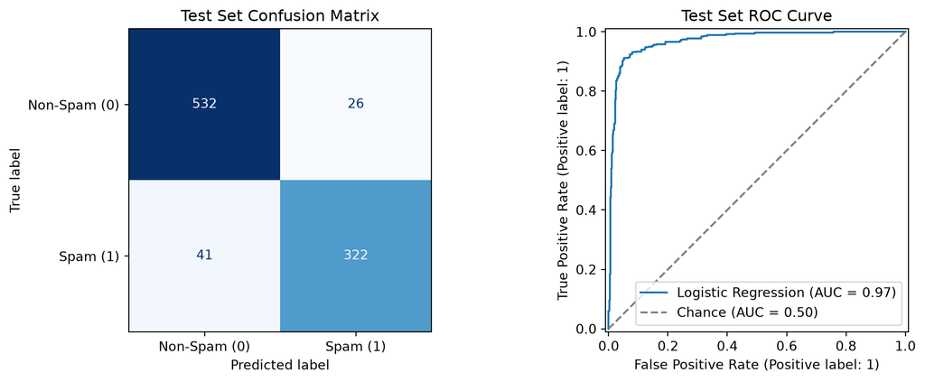

Standardized logistic regression coefficients represent the change in log-odds of an email being classified as spam per 1 standard deviation increase in each feature.

```
Top 8 Spam-Increasing Features:
```

|  | feature | coefficient | odds_ratio_1sd |
| --- | --- | --- | --- |
| 52 | char_freq_$ | 1.5222 | 4.5824 |
| 55 | capital_run_length_longest | 1.3209 | 3.7468 |
| 15 | word_freq_free | 0.8908 | 2.4371 |
| 6 | word_freq_remove | 0.8885 | 2.4315 |
| 22 | word_freq_000 | 0.7469 | 2.1105 |
| 3 | word_freq_3d | 0.7174 | 2.0491 |
| 53 | char_freq_# | 0.5261 | 1.6923 |
| 16 | word_freq_business | 0.4683 | 1.5973 |

```
Top 8 Non-Spam (Ham)-Favoring Features:
```

|  | feature | coefficient | odds_ratio_1sd |
| --- | --- | --- | --- |
| 26 | word_freq_george | -4.0760 | 0.0170 |
| 24 | word_freq_hp | -2.8263 | 0.0592 |
| 41 | word_freq_meeting | -1.7744 | 0.1696 |
| 40 | word_freq_cs | -1.6109 | 0.1997 |
| 28 | word_freq_lab | -1.1920 | 0.3036 |
| 25 | word_freq_hpl | -1.0804 | 0.3395 |
| 45 | word_freq_edu | -1.0355 | 0.3550 |
| 43 | word_freq_project | -0.9383 | 0.3913 |

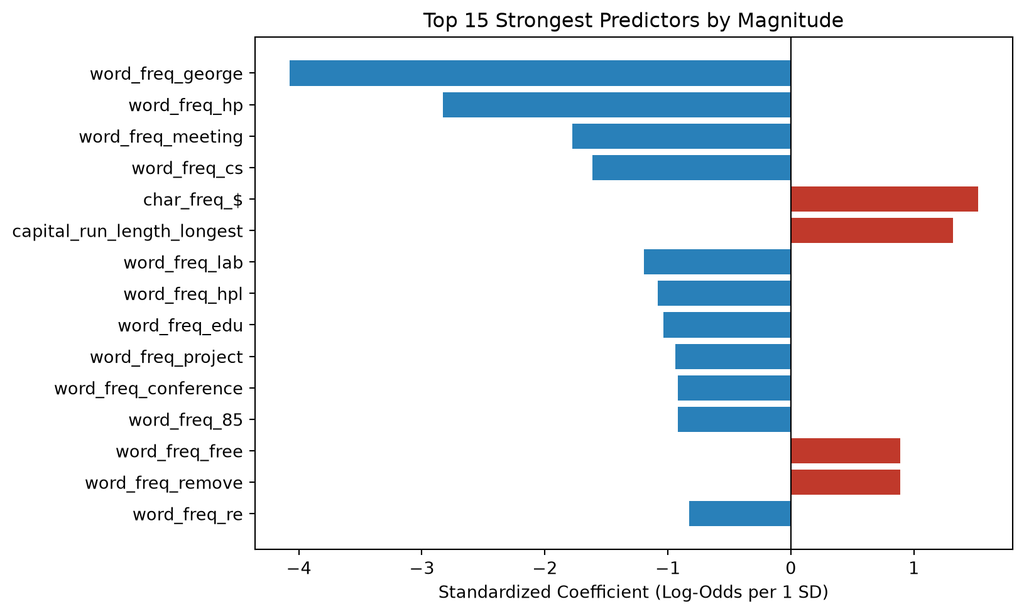

## Limitations

1. 1999 temporal snapshot: Modern spam frequently relies on URLs, image-only messages, spoofing, and evolving vocabulary rather than late-1990s bulk-email keywords.
2. Corporate source bias: Non-spam examples come heavily from Hewlett-Packard Labs inboxes, meaning corpus-specific terms (hp, george) reflect that specific environment rather than general user mail.
3. Decision threshold trade-off: Lowering the probability threshold from 0.50 increases recall (catching more spam) at the cost of higher false positives (flagging legitimate messages), whereas raising it protects legitimate mail at the expense of letting more spam through.

## References

Hopkins, M., Reeber, E., Forman, G., & Suermondt, J. (1999). *Spambase* [Dataset]. UCI Machine Learning Repository. https://doi.org/10.24432/C53G6X